# NAPED — Projeto Mentoria ENAMED | 2026

Centro Universitário Afya · São João del-Rei

Projeto Mentoria ENAMED

Acompanhamento individualizado dos estudantes de Medicina na preparação para o ENAMED

NAPED · Iniciativa da Afya Nacional · Portfólio 2026.1

Iniciativa da Afya Nacional que estrutura o acompanhamento individualizado dos estudantes de Medicina na preparação para o ENAMED, por meio de mentores docentes capacitados pelo NAPED para atuar com escuta ativa, acolhimento e acompanhamento das trajetórias acadêmicas e emocionais dos estudantes.

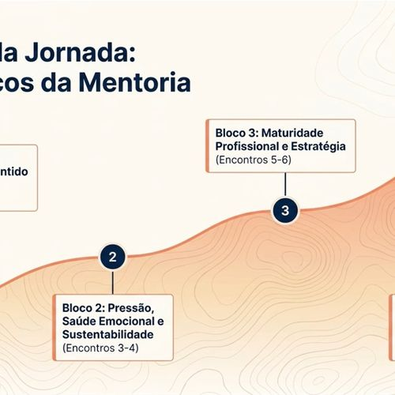

[figure not shown]

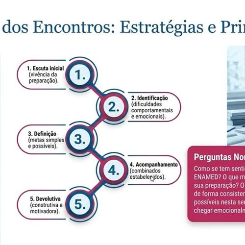

[figure not shown]

35

alunos presentes nos encontros até julho

9

grupos de mentoria · ≤10 alunos cada

Quinzenal

cadência dos encontros com estudantes

Maio de 2026

Treinamento de Mentores — Medicina

O NAPED conduziu o treinamento dos docentes-mentores da Afya São João del Rei, transpondo a metodologia nacional do projeto para o contexto local. Os mentores foram capacitados a conduzir os encontros com segurança, intencionalidade pedagógica e vínculo com os estudantes.

**Bloco 1**Trajetória, Pertencimento e Sentido

**Bloco 2**Pressão, Saúde Emocional e Sustentabilidade

**Bloco 3**Maturidade Profissional e Estratégia

**Bloco 4**Identidade Médica e Projeção Futura

Junho de 2026

Formação de Mentores e Acompanhamento dos Estudantes

O programa foi estruturado com encontros quinzenais de uma hora, em grupos reduzidos de até 10 alunos, orientados pelo NAPED/NED. A metodologia — apresentada por Denny Almeida — capacita os mentores a atuar com escuta inicial, identificação de necessidades, definição de metas, acompanhamento contínuo e devolutiva, acolhendo as trajetórias acadêmicas e emocionais dos estudantes rumo ao ENAMED.

Comunicação e Engajamento

Grupo Mentores Medicina 2026

A equipe de mentores mantém comunicação contínua para alinhamento metodológico, compartilhamento de materiais e apoio recíproco na condução dos encontros.

[figure not shown]

[figure not shown]

Material Didático

"Mentoria Enamed" — MP 1.370/2026

Material produzido pelo mentor **Pedro Delabrida** para explicar aos alunos os impactos da Medida Provisória 1.370/2026 sobre o ENAMED, o CRM e o acesso à Residência Médica.

[figure not shown]

[figure not shown]

[figure not shown]

Apresentação completa (9 slides) disponível na página de Comprovações.

Navegar pelo portfólio

Centro Universitário Afya · São João del-Rei · MG